# Evaluating the Effectiveness of NYC Subway Accessibility for Schools

DSAN 6750 / PPOL 6805: GIS for Spatial Data Science

Author

Affiliation

Rongmu Sun

Georgetown University

## Introduction

The New York City subway system is one of the largest and most extensive public transit networks in the world, playing a crucial role in the daily lives of millions of residents and visitors. With over 400 stations and miles of track, the subway serves as a vital lifeline for transportation across the city. While the subway network is designed to connect people to key urban areas, its effectiveness in providing access to essential public facilities such as schools remains a critical question for urban planning and policy.

This project aims to evaluate the effectiveness of the NYC subway system in providing accessibility to schools. Schools are fundamental public facilities that require reliable and equitable access for students, teachers, and staff. By analyzing the spatial relationship between subway lines and schools, this study seeks to determine how well the subway network serves the educational needs of the city’s population.

The primary objective of this study is to assess the accessibility of NYC subway lines to schools by measuring the proportion of schools located within a walkable distance (0.5 miles) of a subway station. The study will also identify underserved areas and provide insights for improving transit accessibility to schools.

## Hypothesis

“The NYC subway system is highly effective in providing access to schools, with a significant proportion of schools located within 0.5 miles of a subway line.”

Null Hypothesis (H0): There is no significant difference in accessibility to schools compared to a random distribution of subway lines. The observed coverage rate is due to random chance.

Alternative Hypothesis (H1): The NYC subway system is designed to provide effective access to schools, resulting in a higher-than-random school coverage rate.

This hypothesis explicitly relates to second-order properties, as it evaluates the spatial relationships between two datasets:

Subway lines (spatial features): Representing the transit infrastructure. Schools (spatial points): Representing educational facilities.

## Exploratory Data Analysis (EDA)

Here we plot the base GIS objects we’re analyzing: the location of each **school points** (in red) and each **subway line** (in blue).

```r
library(tidyverse) |> suppressPackageStartupMessages()
library(sf) |> suppressPackageStartupMessages()
library(mapview) |> suppressPackageStartupMessages()
library(units) |> suppressPackageStartupMessages()
library(spdep) |> suppressPackageStartupMessages()
library(ggplot2) |> suppressPackageStartupMessages()
```

```r
subway_path <- "Subway Lines NYC"
school_path <- "SchoolPoints_APS_2024_08_28"

subway_lines <- st_read(file.path(subway_path, "geo_export_175db71c-ebef-4b11-98b7-2e22d21d3e02.shp"))
school_points <- st_read(file.path(school_path, "SchoolPoints_APS_2024_08_28.shp"))
subway_lines <- st_transform(subway_lines, crs = 4326)
school_points <- st_transform(school_points, crs = 4326)
```

```r
subway_bbox <- st_bbox(subway_lines)
print(subway_bbox)
```

```
     xmin      ymin      xmax      ymax
-74.03088  40.57559 -73.75541  40.90312
```

```r
school_points <- school_points %>%
  filter(
    st_coordinates(.)[, 1] >= subway_bbox["xmin"] &  # Longitude >= min X
    st_coordinates(.)[, 1] <= subway_bbox["xmax"] &  # Longitude <= max X
    st_coordinates(.)[, 2] >= subway_bbox["ymin"] &  # Latitude >= min Y
    st_coordinates(.)[, 2] <= subway_bbox["ymax"]    # Latitude <= max Y
  )
```

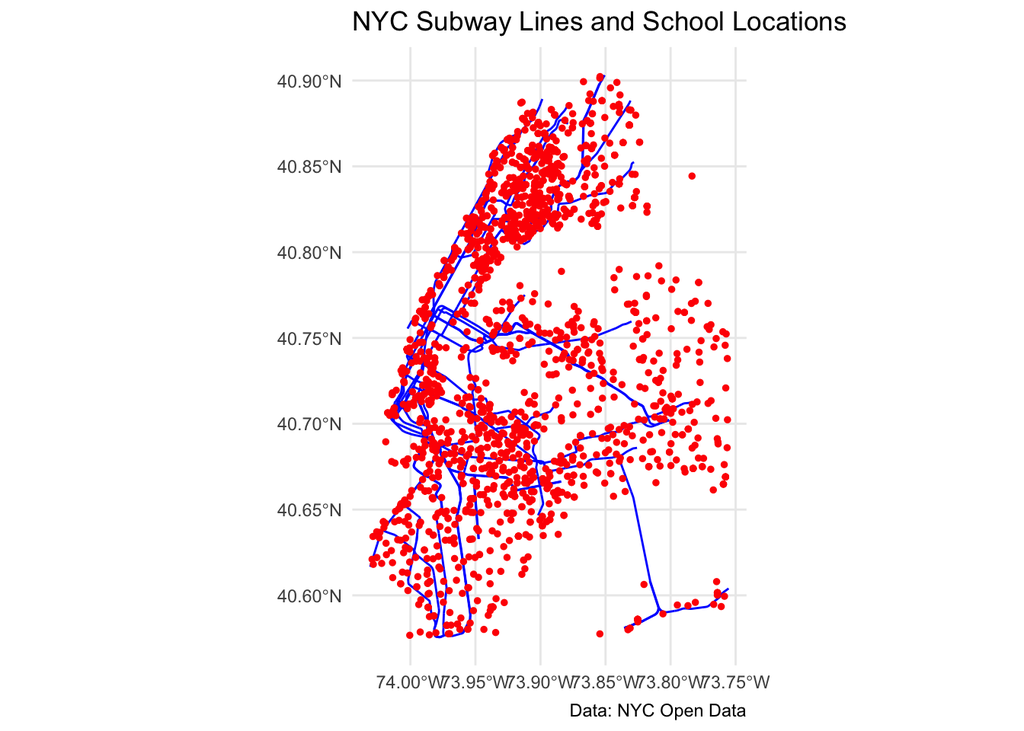

```r
ggplot() +
  geom_sf(data = subway_lines, color = "blue", size = 0.5) +
  geom_sf(data = school_points, color = "red", size = 1) +
  labs(title = "NYC Subway Lines and School Locations",
       caption = "Data: NYC Open Data") +
  theme_minimal()
```

```r
coords <- st_coordinates(school_points)

nb <- knearneigh(coords, k = 5)
listw <- nb2listw(knn2nb(nb))

moran <- moran.test(coords[, 1], listw)
print(moran)
```

```
    Moran I test under randomisation

data:  coords[, 1]
weights: listw

Moran I statistic standard deviate = 71.881, p-value < 2.2e-16
alternative hypothesis: greater
sample estimates:
Moran I statistic       Expectation          Variance
     0.9958242482     -0.0005555556      0.0001921442
```

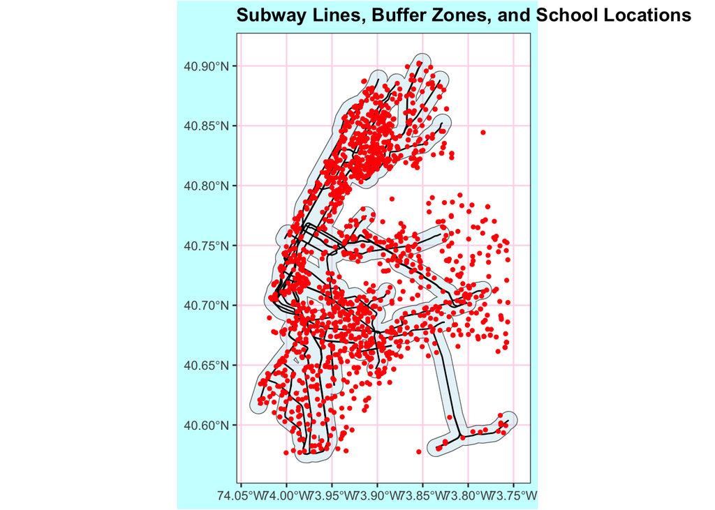

```r
subway_buffers <- st_buffer(subway_lines, dist = 804.67)
subway_buffers <- st_union(subway_buffers)
subway_buffers <- st_sf(geometry = subway_buffers)

ggplot() +
  geom_sf(data = subway_buffers, fill = "light blue", alpha = 0.3) +
  geom_sf(data = subway_lines, color = "black") +
  geom_sf(data = school_points, color = "red", size = 1) +
  labs(title = "Subway Lines, Buffer Zones, and School Locations")
```

```r
school_points <- st_make_valid(school_points)
```

```r
# Validate geometries in school_points
invalid_schools <- school_points[!st_is_valid(school_points), ]
cat("Number of invalid geometries in school_points:", nrow(invalid_schools), "\n")
```

```
Number of invalid geometries in school_points: 0
```

```r
# Fix invalid geometries in school_points
school_points <- st_make_valid(school_points)

# Validate geometries in subway_buffers
invalid_buffers <- subway_buffers[!st_is_valid(subway_buffers), ]
cat("Number of invalid geometries in subway_buffers:", nrow(invalid_buffers), "\n")
```

```
Number of invalid geometries in subway_buffers: 1
```

```r
# Fix invalid geometries in subway_buffers
subway_buffers <- st_make_valid(subway_buffers)
```

```r
schools_within_buffer <- st_join(school_points, subway_buffers, join = st_intersects, left = FALSE)

total_schools <- nrow(school_points)
schools_in_buffer <- nrow(schools_within_buffer)
schools_outside_buffer <- total_schools - schools_in_buffer

cat("Total Schools:", total_schools, "\n")
```

```
Total Schools: 1801
```

```r
cat("Schools Within Buffer:", schools_in_buffer, "\n")
```

```
Schools Within Buffer: 1472
```

```r
cat("Schools Outside Buffer:", schools_outside_buffer, "\n")
```

```
Schools Outside Buffer: 329
```

```r
coverage_percentage <- (schools_in_buffer / total_schools) * 100
cat("School Coverage Percentage:", coverage_percentage, "%\n")
```

```
School Coverage Percentage: 81.73237 %
```

```r
distances <- st_distance(school_points, subway_lines)
min_distances <- apply(distances, 1, min)

school_points$min_distance_to_subway <- as.numeric(min_distances)

average_distance <- mean(min_distances)
cat("Average Distance to Subway (meters):", average_distance, "meters\n")
```

```
Average Distance to Subway (meters): 582.5783 meters
```

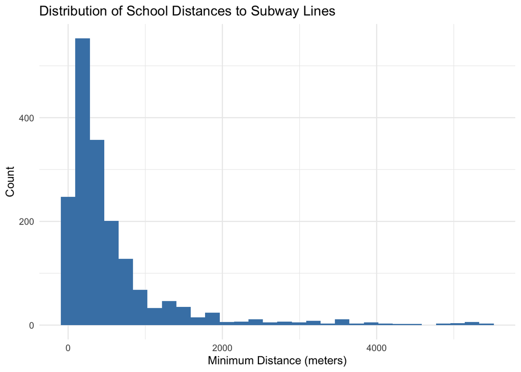

```r
ggplot(data = as.data.frame(school_points)) +
  geom_histogram(aes(x = min_distance_to_subway), bins = 30, fill = "steelblue") +
  labs(title = "Distribution of School Distances to Subway Lines",
       x = "Minimum Distance (meters)",
       y = "Count") +
  theme_minimal()
```

## Hypothesis Testing (Regression)

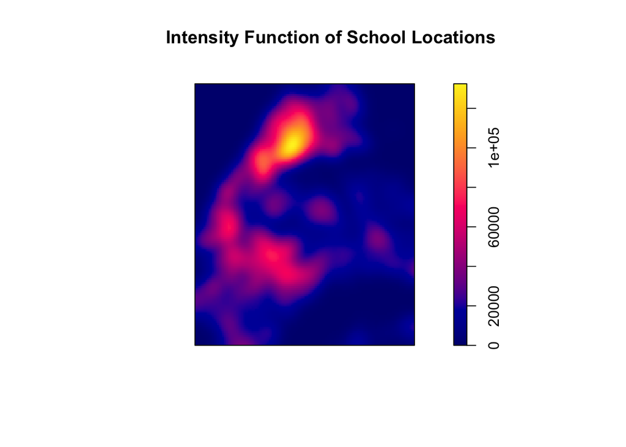

```r
library(spatstat)

# Convert school points to a spatstat object
school_ppp <- as.ppp(st_coordinates(school_points), W = as.owin(st_bbox(school_points)))

# Estimate the intensity function
intensity <- density(school_ppp, sigma = 0.01)  # Adjust sigma for smoothing

# Visualize the intensity function
plot(intensity, main = "Intensity Function of School Locations")
```

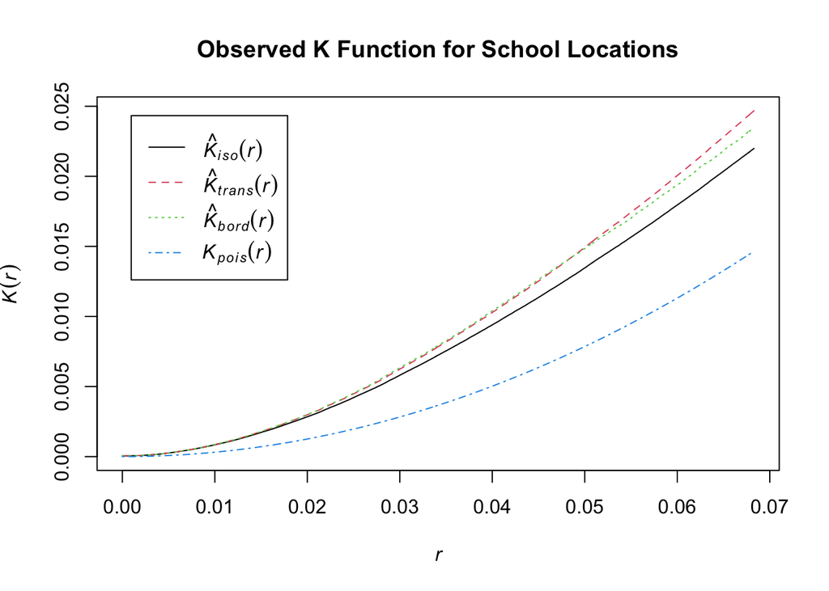

```r
# Compute the K function for observed school locations
k_obs <- Kest(school_ppp)

# Plot the observed K function
plot(k_obs, main = "Observed K Function for School Locations")
```

```r
set.seed(6750)

# Run 999 Monte Carlo simulations
n_simulations <- 999
k_sim <- envelope(school_ppp, Kest, nsim = n_simulations)
```

[output not shown]

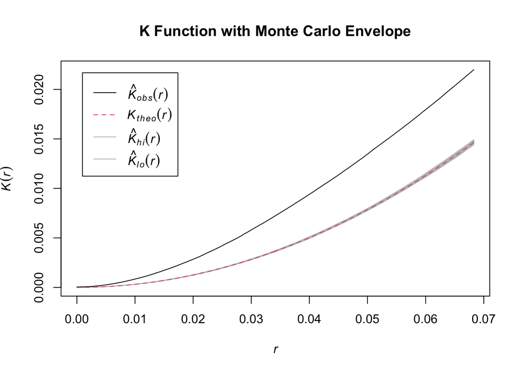

```r
# Visualize the envelope of simulated K functions
plot(k_sim, main = "K Function with Monte Carlo Envelope")
```

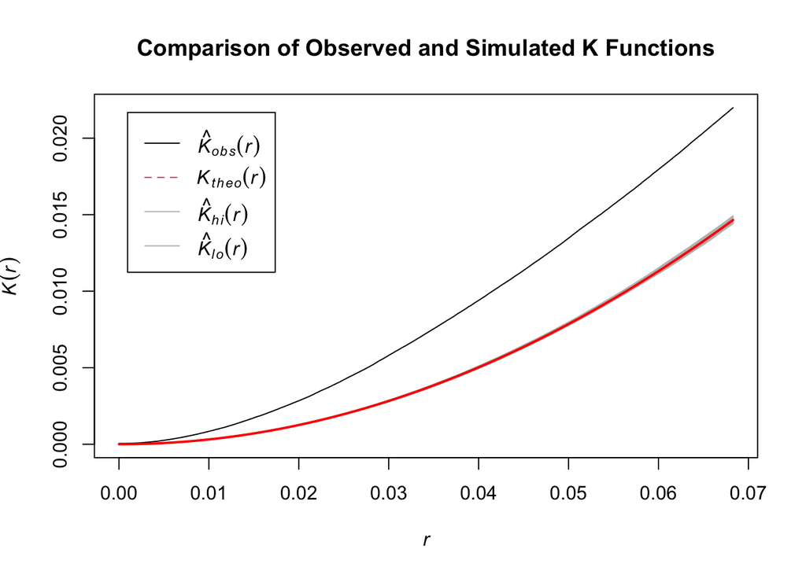

```r
# Overlay observed K function with the simulated envelope
plot(k_sim, main = "Comparison of Observed and Simulated K Functions")
lines(k_obs, col = "red", lwd = 2)  # Add observed K function
```

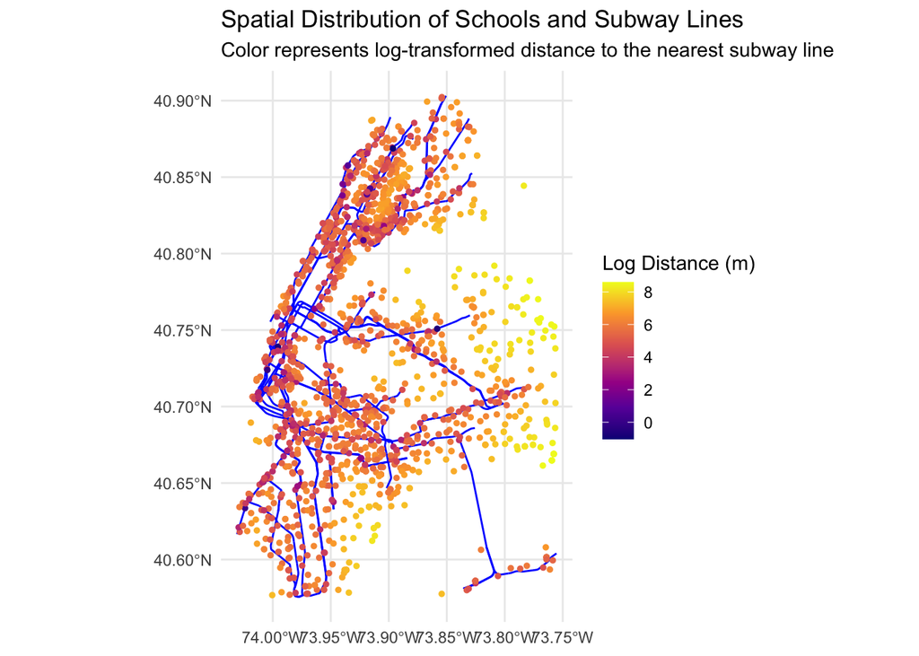

```r
# Plot the intensity of schools and subway lines
library(ggplot2)

ggplot() +
  geom_sf(data = subway_lines, color = "blue", size = 0.5) +
  geom_sf(data = school_points, aes(color = log(min_distance_to_subway)), size = 1) +
  scale_color_viridis_c(option = "plasma", name = "Log Distance (m)") + # Apply a viridis color scale for better visualization
  labs(
    title = "Spatial Distribution of Schools and Subway Lines",
    subtitle = "Color represents log-transformed distance to the nearest subway line"
  ) +
  theme_minimal()
```

```r
library(raster)
# Extract density values for each school
density_raster <- raster(intensity)
school_points$density <- raster::extract(density_raster, st_coordinates(school_points))
```

```r
# Calculate the correlation between school density and proximity to subway lines
correlation <- cor(school_points$min_distance_to_subway, school_points$density, use = "complete.obs")
cat("Correlation between school density and subway proximity:", correlation, "\n")
```

```
Correlation between school density and subway proximity: -0.3362262
```

```r
model <- lm(density ~ min_distance_to_subway, data = school_points)
summary(model)
```

```
Call:
lm(formula = density ~ min_distance_to_subway, data = school_points)

Residuals:
   Min     1Q Median     3Q    Max
-49631 -20562  -5763  13446  87596

Coefficients:
                        Estimate Std. Error t value Pr(>|t|)
(Intercept)            56319.059    785.273   71.72   <2e-16 ***
min_distance_to_subway   -12.019      0.794  -15.14   <2e-16 ***
---
Signif. codes:  0 '***' 0.001 '**' 0.01 '*' 0.05 '.' 0.1 ' ' 1

Residual standard error: 26920 on 1798 degrees of freedom
  (1 observation deleted due to missingness)
Multiple R-squared:  0.113, Adjusted R-squared:  0.1126
F-statistic: 229.2 on 1 and 1798 DF,  p-value: < 2.2e-16
```

## Discussion

Observed Pattern:

The clustering of schools could be related to urban planning policies, population density, or access to infrastructure (e.g., proximity to subway lines).

Relationship:

Statistical Significance Both the intercept and slope are highly significant (p<2e−16). The significant negative slope indicates that schools are more densely clustered closer to subway lines, supporting the Alternative Hypothesis (H₁).

This aligns with urban planning principles, where schools are often placed near transit hubs for accessibility.

Based on the regression results:

The NYC subway system is effective in providing access to schools, as evidenced by the clustering of schools near subway lines.